# Repeating analysis with Mature only

# Next main section: graphing log2 of cpm

`r`r

```r
#calculating CPM
cpmInput<- MatureCounts
#calculate factor to multiply all counts for to convert to CPM
totalCounts<- colSums(cpmInput)
TotalCountsPM<- 1000000/totalCounts
#Convert all counts to CPM
CPM<-cpmInput*TotalCountsPM
#get rid of any miRNAs that have a 0 counts for any sample- can't take log2 of it
CPMFinal<- CPM[apply(CPM, 1, function(row) all(row !=0 )),]
#log2 of CPM
CPMLog<- log2(CPMFinal)
#Get miRNA info. Need: whether or not it was targeted + whether or not it was DE
#Add in target info- add column for whether or not the species was targeted
targets<- c('hsa-miR-486-5p','hsa-miR-92a-3p','hsa-miR-451a')
CPMLog$target<- rownames(CPMLog) %in% targets
#Add in DE info- using DESeq2 results from targets included analysis. Import data here.
resOrdered<- read.csv(paste(wd, \DESeq2Results/MatureOnly_TargetsIncluded_Pairwise_DESeq2Results_103119.csv\, sep =\\))
rownames(resOrdered)<- resOrdered$X
resOrdered<- resOrdered[,-1]
sig<- resOrdered[resOrdered$padj<0.05,]
CPMLog$Sig<- rownames(CPMLog) %in% rownames(sig)
#Add in third column, used to color points in graph. Add together target/sig columns. If it's a target and sig, it'll be 2, if it's just sig it'll be 1, if it's neither it'll be 0.
TargetSig<- CPMLog[,17:18]
CPMLog$Color<- as.factor(rowSums(TargetSig))
CPMLog$Color<- gsub(2, \Target\, CPMLog$Color)
CPMLog$Color<- gsub(1, \DE\, CPMLog$Color)
CPMLog$Color<- gsub(0, \Not DE\, CPMLog$Color)
#calculating CPM
cpmInput<- MatureCounts
```

`r`r

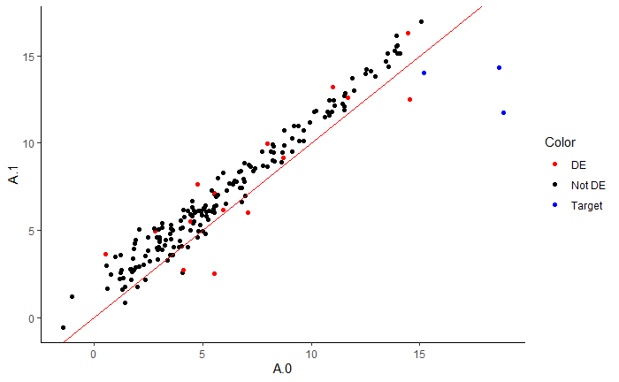

```r
#Looking at sample A- get average for all 3 Inputs
CPMLogA<- CPMLog[,c(1:3, 9:11,19)]
CPMLogA$A.0<- rowMeans(CPMLogA[,1:3])
CPMLogA$A.1<- rowMeans(CPMLogA[,4:6])
CPMLogA<- CPMLogA[,c(8,9,7)]
pA<- ggplot(CPMLogA, aes(x=A.0, y=A.1, color=Color))+
  geom_point()+
  geom_abline(slope=1, color=\red\)+
  scale_colour_manual(values=c(\red\,\black\, \blue\))+
  theme_classic()

pA
```

`r`r

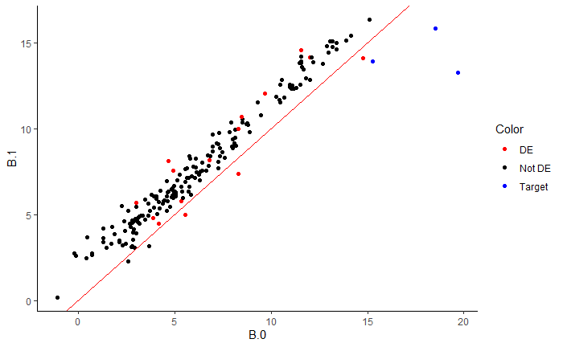

```r
#Looking at sample B- get average for all 3 Inputs
CPMLogB<- CPMLog[,c(4:6, 12:14,19)]
CPMLogB$B.0<- rowMeans(CPMLogB[,1:3])
CPMLogB$B.1<- rowMeans(CPMLogB[,4:6])
CPMLogB<- CPMLogB[,c(8,9,7)]
pB<- ggplot(CPMLogB, aes(x=B.0, y=B.1, color=Color))+
  geom_point()+
  geom_abline(slope=1, color=\red\)+
  scale_colour_manual(values=c(\red\,\black\, \blue\))+
  theme_classic()

pB
```

`r`r

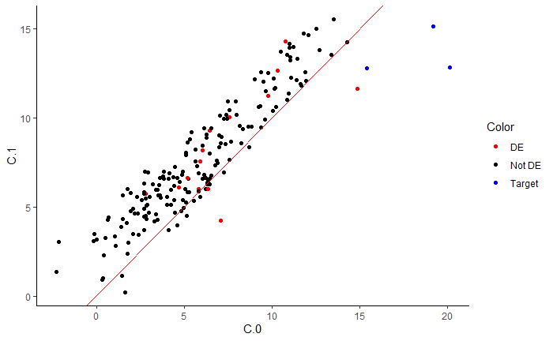

```r
#For sample C
CPMLogC<- CPMLog[,c(7, 15,19)]
colnames(CPMLogC)<- c(\C.0\, \C.1\, \Color\)
pC<- ggplot(CPMLogC, aes(x=C.0, y=C.1, color=Color))+
  geom_point()+
  geom_abline(slope=1, color=\red\)+
  scale_colour_manual(values=c(\red\,\black\, \blue\))+
  theme_classic()

pC
```

`r`r

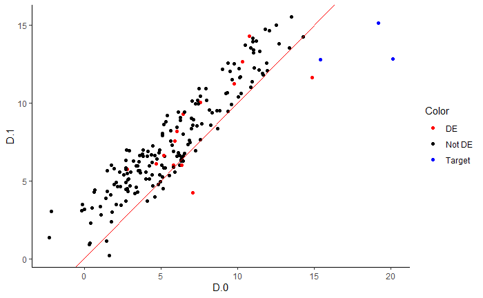

```r
#For sample D
CPMLogD<- CPMLog[,c(7, 15,19)]
colnames(CPMLogD)<- c(\D.0\, \D.1\, \Color\)
pD<- ggplot(CPMLogD, aes(x=D.0, y=D.1, color=Color))+
  geom_point()+
  geom_abline(slope=1, color=\red\)+
  scale_colour_manual(values=c(\red\,\black\, \blue\))+
  theme_classic()

pD
```

`r`r

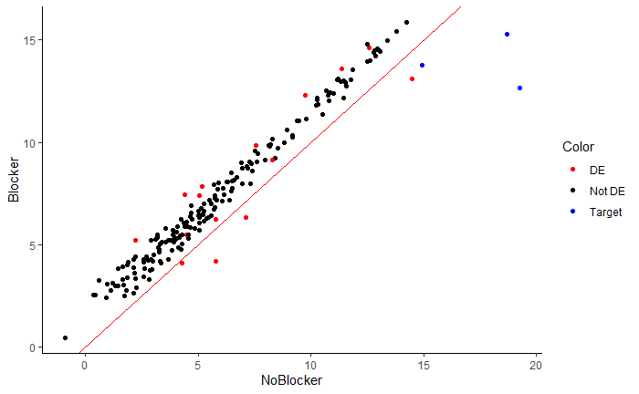

```r
#Averaging values across al 4 samples
CPMLogAll<- CPMLog
CPMLogAll$NoBlocker<- rowMeans(CPMLogAll[,1:8])
CPMLogAll$Blocker<- rowMeans(CPMLogAll[,9:16])
CPMLogAll<- CPMLogAll[,c(20,21,19)]
pMean<- ggplot(CPMLogAll, aes(x=NoBlocker, y=Blocker, color=Color))+
  geom_point()+
  geom_abline(slope=1, color=\red\)+
  scale_colour_manual(values=c(\red\,\black\, \blue\))+
  theme_classic()

pMean
```

Putting A-D together on one plot:

`r`r

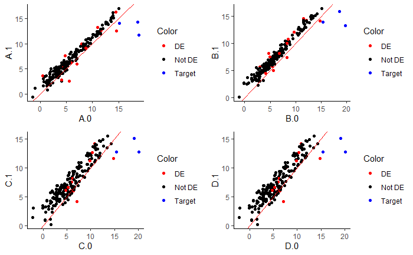

```r
grid.arrange(pA, pB, pC, pD, nrow=2)
```

# Benefits of blocker: better detection of miRNAs with low counts

Want to look at the number of species that pass a certain numerical threshold for counts- i.e., how many species get at least 100 counts for blocker vs no blocker?

However- big problem: the blocker samples have about 50% of the total reads that no blocker do. So the no blocker will have a much better detection of low level expression- during LC, they would have had a much better chance of picking up lowly expressed miRNAs

So we can’t really just normalize- that doesn’t quite account for this.

The way that meyers et al does it (and for much of their paper- might be a good idea to replicate all the other analyses using this type of normalized counts) is to “downsample” their data

This is meant to simulate having the same number of reads/identical LC

They downsample to 6mill reads- I’m downsampling to about 5 million reads, for no reason at all

# Performing downsampling

`r`r

```r
# Here, I'm trying to get colSums of counts close to 5mil for all samples.
#To do this, first I'm getting the proportion you have to multiply noblocker samples by to get to 5 mil and a separate proportion for blocker samples (ends up being ~25% and ~50%).
#Then use this as the proportion setting in subseq's subsample function.
#Then extract the subsample counts. Do this for both noblocker/blocker samples, then merge together.
#Note this is slightly different than meyers et al, and I might want to figure out a way to do it exactly the way they do

#get proportion you need to multiply by to get to close to 5mil (a little off, since I'm using the average colsums across all 8 blocker/noblocker samples)
noblockerProportion<- 5000000/mean(colSums(MatureCounts[,1:8]))
blockerProportion<- 5000000/mean(colSums(MatureCounts[,9:16]))
#subset the raw count matrix into blocker/noblocker
noblockerCounts<- MatureCounts[,1:8]
blockerCounts<- MatureCounts[,9:16]
#set treatment- doesn't actually matter, bc I'm not using this for downstream. They're not set to the correct treatments (actually all \blocker\ or \noblocker\, but subseq doesn't let you have all of 1 treatment type as input)
Treatment<- as.factor(c(rep(\noblocker\, 4), rep(\blocker\, 4)))
#get subsampled count matrix for noblocker samples
noblockerSubsample<- subsample(noblockerCounts, noblockerProportion, method=\DESeq2\, treatment=Treatment)
```

[output not shown]

# Using the subsampled count matrix generated above, recreate figure 3 from meyers et al: looking at the change in the # of miRNAs that pass a variety of count thresholds for blocked vs unblocked samples.

Kind of different to what they’re plotting, but same idea

`r`r

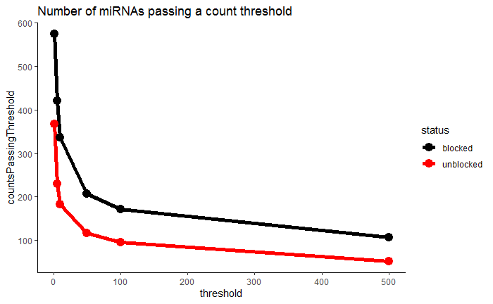

```r
#read in data
SampledCounts<- read.csv(paste(wd, \OtherResults/DownSampledCounts_MatureOnly_metaseqR_110119.csv\, sep =\\))
rownames(SampledCounts)<- SampledCounts$X
SampledCounts<- SampledCounts[,-1]
#Collapse technical replicates (by just taking mean of counts)
unblockedCounts<- as.data.frame(SampledCounts[,1:8])
unblockedCounts$ACollapsed<- rowMeans(unblockedCounts[,1:3])
unblockedCounts$BCollapsed<- rowMeans(unblockedCounts[,4:6])
unblockedCounts<-unblockedCounts[,c(9,10,7,8)]
#get mean counts across all 4 samples
unblockedCountsMeans<- as.data.frame((rowMeans(unblockedCounts)))
#number that pass thresholds:
unblockedPassThresholds<- data.frame(threshold=c(1,5,10,50,100,500), countsPassingThreshold=c(sum(unblockedCountsMeans>1),sum(unblockedCountsMeans>5),sum(unblockedCountsMeans>10),sum(unblockedCountsMeans>50),sum(unblockedCountsMeans>100),sum(unblockedCountsMeans>500)))
#blocked: collapse technical replicates (by just taking mean of counts)
blockedCounts<- as.data.frame(SampledCounts[,9:16])
blockedCounts$ACollapsed<- rowMeans(blockedCounts[,1:3])
blockedCounts$BCollapsed<- rowMeans(blockedCounts[,4:6])
blockedCounts<-blockedCounts[,c(9,10,7,8)]
#get mean counts across all 4 samples
blockedCountsMeans<- as.data.frame((rowMeans(blockedCounts)))
#number that pass thresholds:
blockedPassThresholds<- data.frame(threshold=c(1,5,10,50,100,500), countsPassingThreshold=c(sum(blockedCountsMeans>1),sum(blockedCountsMeans>5),sum(blockedCountsMeans>10),sum(blockedCountsMeans>50),sum(blockedCountsMeans>100),sum(blockedCountsMeans>500)))
#combine into one, adding in an extra column for blocker status
unblockedPassThresholds$status<- rep(\unblocked\,6)
blockedPassThresholds$status<- rep(\blocked\,6)
passThreshold<-rbind(unblockedPassThresholds,blockedPassThresholds)
#plot
p<- ggplot(passThreshold, aes(x=threshold, y=countsPassingThreshold, color=status))+
             geom_line(size=2)+
  geom_point(size=4)+
  scale_color_manual(values=c(\black\, \red\))+
  ggtitle(\Number of miRNAs passing a count threshold\)+
  theme_classic()
p
```

# doing the above, but not taking the mean. still collapse technical, but keep a/b/c/d info. Add in a 4th column in the final table with sample type. Then subtract the #passing threshold for a/b/c/d individually from blocker vs no blocker, then graph.

whoowhweeee

`r`r

```r
#write (awful) function that takes a column of counts and returns the number of species that pass the 6 threshold already written into the function, bc i am stupid
CountsPassingThreshold<- function(counts){
  return(c(sum(counts>1),sum(counts>5),sum(counts>10),sum(counts>50),sum(counts>100),sum(counts>500),sum(counts>1000)))
}
#Get counts passing threshold for unblocked samples, then transform data- 4 columns: ID (A/b/c/d), threshold, #of species that passed that threshold, and blocker status
unblockedPassThreshold<- as.data.frame(apply(unblockedCounts, 2, CountsPassingThreshold))
rownames(unblockedPassThreshold)<- c(1,5,10,50,100,500,1000)
colnames(unblockedPassThreshold)<- c(\A\, \B\, \C\, \D\)
#add 4th column: mean of all samples
unblockedPassThreshold$Mean<- rowMeans(unblockedPassThreshold)
unblockedPassThreshold<- as.data.frame(t(unblockedPassThreshold))
unblockedPassThreshold$ID<- rownames(unblockedPassThreshold)
#reformat- melt
unblockedPassThreshold<- melt(unblockedPassThreshold)
```

`r`r

```r
colnames(unblockedPassThreshold)<- c(\ID\, \threshold\,\speciesPassingThreshold\)
unblockedPassThreshold$status<- rep(\unblocked\, 35)
unblockedPassThreshold$threshold<- as.integer(as.character((unblockedPassThreshold$threshold)))
#Get counts passing threshold for blocked samples, then transform data- 4 columns: ID (A/b/c/d), threshold, #of species that passed that threshold, and blocker status
blockedPassThreshold<- as.data.frame(apply(blockedCounts, 2, CountsPassingThreshold))
rownames(blockedPassThreshold)<- c(1,5,10,50,100,500,1000)
colnames(blockedPassThreshold)<- c(\A\, \B\, \C\, \D\)
#add 4th column: mean of all samples
blockedPassThreshold$Mean<- rowMeans(blockedPassThreshold)
blockedPassThreshold<- as.data.frame(t(blockedPassThreshold))
blockedPassThreshold$ID<- rownames(blockedPassThreshold)
#reformat- melt
blockedPassThreshold<- melt(blockedPassThreshold)
```

`r`r

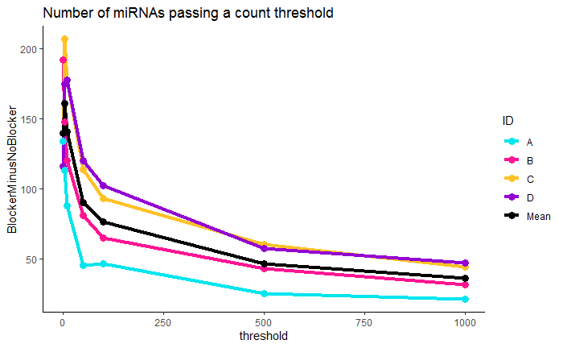

```r
colnames(blockedPassThreshold)<- c(\ID\, \threshold\,\speciesPassingThreshold\)
blockedPassThreshold$status<- rep(\blocked\, 35)
blockedPassThreshold$threshold<- as.integer(as.character((blockedPassThreshold$threshold)))
#combine into one
passThreshold<-rbind(unblockedPassThreshold,blockedPassThreshold)
#reformat so that you have 4 columns: ID, threshold, #species passing in noblocker, #species passing in blocker
PT<-data.frame(passThreshold$ID[1:35], passThreshold$threshold[1:35],passThreshold$speciesPassingThreshold[1:35], passThreshold$speciesPassingThreshold[36:70])
colnames(PT)<- c(\ID\, \threshold\, \SpeciesPT_noblocker\, \SpeciesPT_blocker\)
#now need to subtract each- i.e., sample A at threshold 1 with no blocker vs with blocker. get those values for all, then plot.
df<- as_tibble(PT)
df<-df%>% group_by(ID) %>% mutate(BlockerMinusNoBlocker=SpeciesPT_blocker-SpeciesPT_noblocker)
df<- as.data.frame(df)
#plot
p<- ggplot(df, aes(x=threshold, y=BlockerMinusNoBlocker, color=ID))+
             geom_line(size=1.5)+
  geom_point(size=3)+
  scale_color_manual(values=c(\turquoise2\, \deeppink1\, \goldenrod1\, \darkviolet\,\black\))+
  ggtitle(\Number of miRNAs passing a count threshold\)+
  theme_classic()
p
```